# Machine Learning

# Machine Learning Assignment

### Aim of Analysis

This analysis will attempt to create a machine learning algorithm to predict the factor variable “classe”. This represents that method for preforming a barbell lift. This analysis will use the data on the characteristics of the movement collected in the training data to predict the classe of the movement.

### Loading the Data

We first load the data sets for the training and test sets from the csv file and remove all columns with the majority of rows containing NA or blank. The first seven variables are also removed as they provide no meaningful information on the prediction.

```r
setwd("~/Documents/Machine Learning")
train <- read.csv("training.csv")
test <- read.csv("test.csv")

train <- train[ , colSums(is.na(train)) < 19000 ]
train <- train[ , colSums(train == "") < 19000 ]
test <- test[ , colSums(is.na(test)) < 19 ]
test <- test[ , colSums(test == "") < 19 ]

train <- train[ , -c(1:7)]
test <- test[ , -c(1:7)]
```

The training set consists of 19622 observations and 53 variables. In this analysis we will be focusing on predicting the classe variable.

```r
summary(train$classe)
```

```
##    A    B    C    D    E
## 5580 3797 3422 3216 3607
```

### Prediction Method

Due to the high number of variables in this data set we will use a random forest method to create a prediction algorithm.

A model fit is created by using all variable to predict the classe variable by using the randomForest package.

```r
library(caret)
library(randomForest)
RFmodFit <- randomForest(classe ~ . , data = train, na.action = na.omit)
```

Once this calculation is completed we get the following final model.

```r
RFmodFit
```

```
##
## Call:
##  randomForest(formula = classe ~ ., data = train, na.action = na.omit)
##                Type of random forest: classification
##                      Number of trees: 500
## No. of variables tried at each split: 7
##
##         OOB estimate of  error rate: 0.3%
## Confusion matrix:
##      A    B    C    D    E  class.error
## A 5578    2    0    0    0 0.0003584229
## B   11 3783    3    0    0 0.0036871214
## C    0   11 3410    1    0 0.0035067212
## D    0    0   23 3191    2 0.0077736318
## E    0    0    1    5 3601 0.0016634322
```

This can be seen in the error plot below as the number of trees are increased.

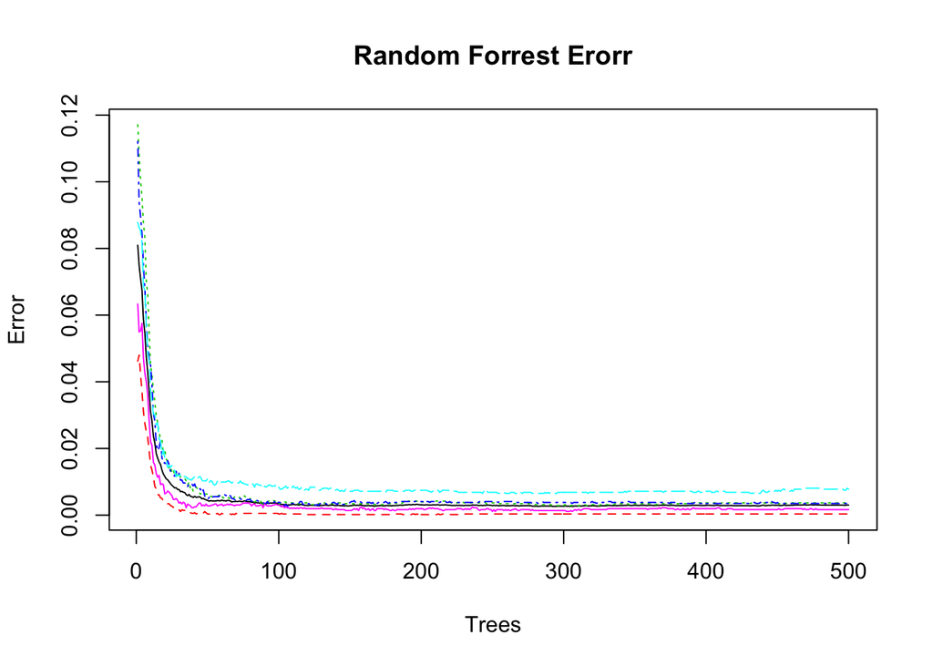

```r
matplot(RFmodFit$err.rate, xlab = "Trees", ylab = "Error", main = "Random Forrest Erorr", type = c("l"))
```

### Prediction of Results

The test data set is now used to test the prediction of of the random forest. Three variables firstly need to have the class converted to match the training data set for the prediction to work.

```r
library(caret)
library(randomForest)
test$magnet_dumbbell_z <- as.numeric(test$magnet_dumbbell_z)
test$magnet_forearm_z <- as.numeric(test$magnet_forearm_z)
test$magnet_forearm_y <- as.numeric(test$magnet_forearm_y)

results <- predict(RFmodFit, newdata = test)

results
```

```
##  1  2  3  4  5  6  7  8  9 10 11 12 13 14 15 16 17 18 19 20
##  B  A  B  A  A  E  D  B  A  A  B  C  B  A  E  E  A  B  B  B
## Levels: A B C D E
```

When the predicted results for the test data set are submitted it delivers 100% accuracy, consistent with the accuracy of the training data set demonstrating over fitting is not an issue with this prediction.